# Correlation analysis report

```
sample data
```

|  | ACCOUNTID | Potential Owner | TATS | Lead Source | Score | Stage | Crop Value | Applying for Credit | Country Of Opps | Amount |
| --- | --- | --- | --- | --- | --- | --- | --- | --- | --- | --- |
| 0 | zcrm_906798000014914022 | RM | 100 | Partner Referral | 6 | 10. Sale Won | Med Val | Yes | Flagship | 114628.00 |
| 1 | zcrm_906798000014914022 | RM | 60 | Partner Referral | 6 | 10. Sale Won | Med Val | Yes | Flagship | 583814.68 |
| 2 | zcrm_906798000017227007 | MB | 60 | Repeat Business | 5 | 10. Sale Won | High Val | No | Flagship | 44587.25 |
| 3 | zcrm_906798000021612349 | SW | 55 | Referral | 40 | 10. Sale Won | High Val | Not Eligible | Flagship | 107813.02 |
| 4 | zcrm_906798000025876052 | SW | 55 | Employee Referral | 11 | 3. Quote Delivered | Med Val | Yes | Flagship | 50000.00 |

```
list of columns
```

```
Index(['ACCOUNTID', 'Potential Owner', 'TATS', 'Lead Source', 'Score', 'Stage',
       'Crop Value', 'Applying for Credit', 'Country Of Opps', 'Amount'],
      dtype='object')
```

## 1) Analysis of 'TATS' with 'Potential Owner'

#### Applying statistical test

```
number of categories= 6
```

```
KruskalResult(statistic=1.7049391633105635, pvalue=0.8882769223525839)
```

numeric= 'TATS'  
category_variable= 'Potential Owner'  
Since, p is not less than .05, we can not reject the null hpothesis We can say that "TATS" does not depend upon the category variable  
Let us study the relationship of median value of "TATS" for each category

#### Median value of TATS per category

|  | Potential Owner | TATS |
| --- | --- | --- |
| 0 | Fern | 20.0 |
| 1 | MB | 10.5 |
| 2 | PR | 9.5 |
| 3 | RM | 10.0 |
| 4 | SW | 8.0 |
| 5 | TC | 15.0 |

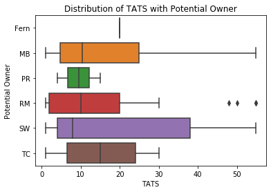

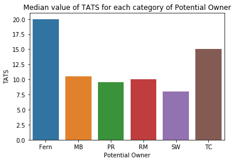

#### Inference

Median time spent is not significantly different for different Potential owner category

## 2) Analysis of 'TATS' with 'Lead Source'

#### Applying statistical test

```
number of categories= 11
```

```
KruskalResult(statistic=25.07054729568026, pvalue=0.0052133766014078224)
```

Since, p is less than .05, we can reject the null hpothesis  
We can say that "TATS" does depends upon the category variable  
Let us study the relationship of median value of "TATS" for each category

#### Median value of TATS per category

|  | Lead Source | TATS |
| --- | --- | --- |
| 0 | Cold Call | 1.0 |
| 1 | Direct Phone Enquiry | 2.0 |
| 2 | Employee Referral | 10.0 |
| 3 | Fairs/Event/Seminar | 15.0 |
| 4 | LinkedIn | 4.0 |
| 5 | Partner Referral | 15.0 |
| 6 | Referral | 17.0 |
| 7 | Repeat Business | 27.5 |
| 8 | Unknown/External Referral | 20.0 |
| 9 | Web Research | 3.0 |
| 10 | Website 'Contact Us' Form | 6.0 |

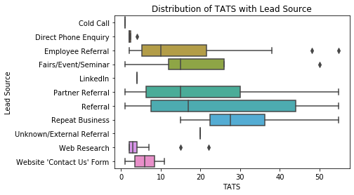

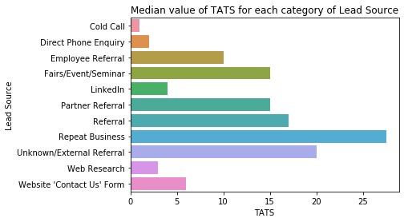

#### Inference

Median time spent is significantly different for different categories

## 3) Analysis of 'TATS' with 'Stage'

#### Applying statistical test

```
number of categories= 11
```

```
KruskalResult(statistic=27.97073017056687, pvalue=0.0018248300788438854)
```

Since, p is less than .05, we can reject the null hpothesis  
We can say that "TATS" depends upon the category variable  
Let us study the relationship of median value of "TATS" for each category

#### Median value of TATS per category

|  | Stage | TATS |
| --- | --- | --- |
| 0 | 1. Value Proposition | 3.0 |
| 1 | 10. Sale Won | 25.0 |
| 2 | 11. On Hold | 30.0 |
| 3 | 12. Closed Lost | 6.0 |
| 4 | 2. Proposal Development | 7.0 |
| 5 | 3. Quote Delivered | 4.0 |
| 6 | 4. Negotiation | 5.0 |
| 7 | 5. Grant Application | 22.0 |
| 8 | 7. Due Diligence | 4.0 |
| 9 | 8. Contract Issued | 14.0 |
| 10 | 9. Contract Signed | 30.0 |

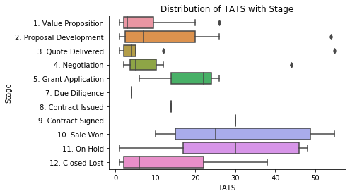

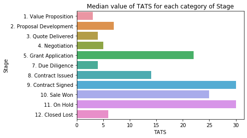

#### Inference

Median time spent is different for different categories

## 4) Analysis of 'TATS' with 'Crop Value'

#### Applying statistical test

```
number of categories= 3
```

```
KruskalResult(statistic=6.41329467133404, pvalue=0.04049214251502794)
```

Since, p is less than .05, we can reject the null hpothesis  
We can say that "TATS" depends upon the category variable  
Let us study the relationship of median value of "TATS" for each category

#### Median value of TATS per category

[output not shown]

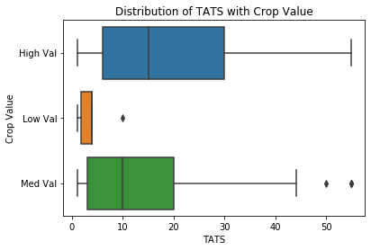

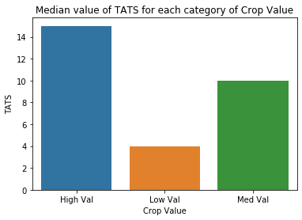

#### Inference

Median time spent is significantly different for different categories

## 5) Analysis of 'TATS' with 'Applying for Credit'

#### Applying statistical test

```
number of categories= 3
```

```
KruskalResult(statistic=0.024224093970376552, pvalue=0.8763160735548344)
```

Since, p is not less than .05, we can not reject the null hpothesis  
We can say that "TATS" does not depend upon Applying for Credit  
Let us visualize the median value of "TATS" for each category

#### Median value of TATS per category

|  | Applying for Credit | TATS |
| --- | --- | --- |
| 0 | Not Eligible | 10.0 |
| 1 | Yes | 14.0 |
| 2 | No | 15.0 |

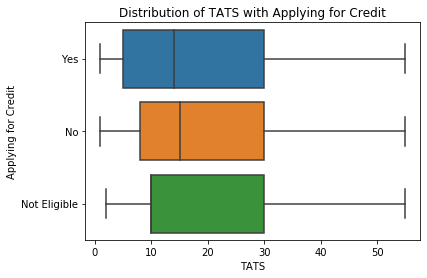

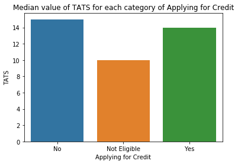

#### Inference

Median time spent is independent of whether the customer is applying for credit

## 6) Analysis of 'TATS' with 'Country Of Operations'

#### Applying statistical test

```
number of categories= 3
```

```
KruskalResult(statistic=0.2734211415062469, pvalue=0.6010460196521787)
```

Since, p is not less than .05, we can not reject the null hpothesis  
We can say that "TATS" does not depend upon the Country of Operations.  
Let us visualize the median value of "TATS" for each category

#### Median value of TATS per category

|  | Country Of Opps | TATS |
| --- | --- | --- |
| 0 | Not IF Focused | 4.0 |
| 1 | IF Focused | 10.0 |
| 2 | Flagship | 10.5 |

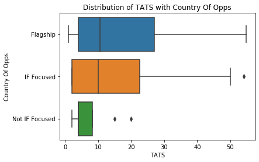

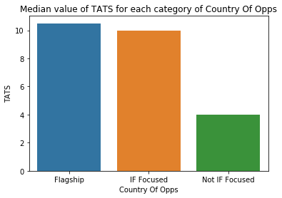

#### Inference

Median time spent is for a 'not IF Focused' is less than others

## 7) Analysis of 'TATS' with 'Score'

#### Visually exploring the relationship between both variables

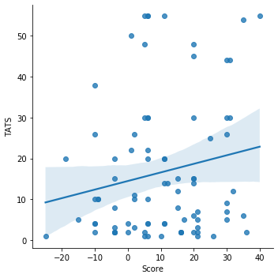

Quantifying the relationship through correlation coefficient

```
(0.17848575162250502, 0.10428830271833621)
```

Since, p is not less than .05, we can not reject the null hpothesis

Both the variables are not significantly correlated

## 8) Analysis of 'TATS' with 'Amount'

#### Visually exploring the relationship between both variables

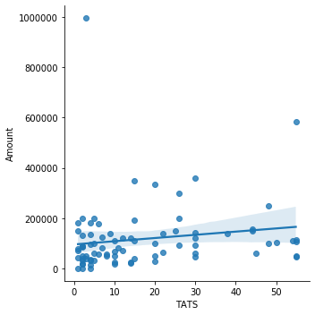

Quantifying the relationship through correlation coefficient

```
(0.15866738088383175, 0.1545120506764831)
```

Since, p is not less than .05, we can not reject the null hpothesis  
Both the variables are not correlated

Correlation coefficient is just .158

#### Inference

Time spent and amount is independent